# Exploratory Data Analysis

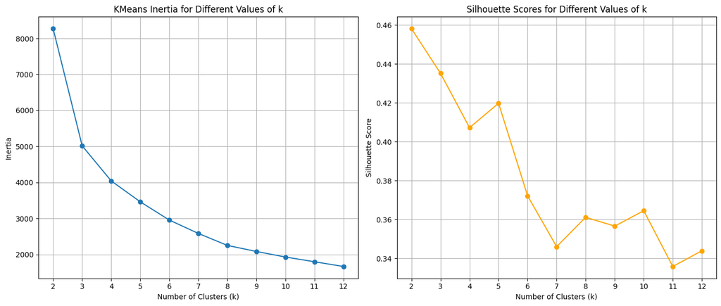

```python
from sklearn.cluster import KMeans
from sklearn.metrics import silhouette_score

max_k = 12

inertia = []
silhoutte_scores = []
k_values = range(2, max_k + 1)

for k in k_values:

    kmeans = KMeans(n_clusters=k, random_state=42, max_iter=1000)

    cluster_labels = kmeans.fit_predict(scaled_data_df)

    sil_score = silhouette_score(scaled_data_df, cluster_labels)

    silhoutte_scores.append(sil_score)

    inertia.append(kmeans.inertia_)

plt.figure(figsize=(14, 6))

plt.subplot(1, 2, 1)
plt.plot(k_values, inertia, marker='o')
plt.title('KMeans Inertia for Different Values of k')
plt.xlabel('Number of Clusters (k)')
plt.ylabel('Inertia')
plt.xticks(k_values)
plt.grid(True)

plt.subplot(1, 2, 2)
plt.plot(k_values, silhoutte_scores, marker='o', color='orange')
plt.title('Silhouette Scores for Different Values of k')
plt.xlabel('Number of Clusters (k)')
plt.ylabel('Silhouette Score')
plt.xticks(k_values)
plt.grid(True)

plt.tight_layout()
plt.show()
```

```python
"""
From the charts, we can see that at k=4 the line slowly decrease
and sihouette score of k=2, 3, 4 is not that much different.
So, from these information we will assume that k=4 is the optimal number of cluster
"""
```

```python
kmeans = KMeans(n_clusters=4, random_state=42, max_iter=1000)

cluster_labels = kmeans.fit_predict(scaled_data_df)

cluster_labels
```

```
array([2, 3, 2, ..., 1, 1, 2])
```

```python
# Assign cluster's name to each record
non_outliers_df["Cluster"] = cluster_labels

non_outliers_df
```

|  | Customer_ID | TotalSpending | Recency | Frequency | Cluster |
| --- | --- | --- | --- | --- | --- |
| 1 | 12347 | 4921.53 | 2 | 222 | 2 |
| 2 | 12348 | 2019.40 | 75 | 51 | 3 |
| 3 | 12349 | 4428.69 | 18 | 175 | 2 |
| 4 | 12350 | 334.40 | 310 | 17 | 1 |
| 5 | 12351 | 300.93 | 375 | 21 | 1 |
| ... | ... | ... | ... | ... | ... |
| 5875 | 18282 | 178.05 | 7 | 12 | 0 |
| 5877 | 18284 | 461.68 | 431 | 28 | 1 |
| 5878 | 18285 | 427.00 | 660 | 12 | 1 |
| 5879 | 18286 | 1296.43 | 476 | 67 | 1 |
| 5880 | 18287 | 4182.99 | 42 | 155 | 2 |

5052 rows × 5 columns

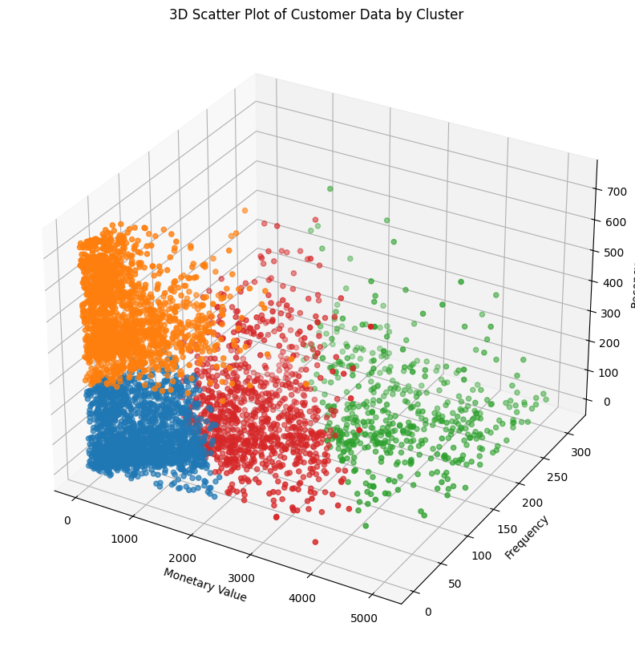

```python
cluster_colors = {0: '#1f77b4',  # Blue
                  1: '#ff7f0e',  # Orange
                  2: '#2ca02c',  # Green
                  3: '#d62728'}  # Red

colors = non_outliers_df['Cluster'].map(cluster_colors)

fig = plt.figure(figsize=(10, 10))
ax = fig.add_subplot(projection='3d')

scatter = ax.scatter(non_outliers_df['TotalSpending'],
                     non_outliers_df['Frequency'],
                     non_outliers_df['Recency'],
                     c=colors,  # Use mapped solid colors
                     marker='o')

ax.set_xlabel('Monetary Value')
ax.set_ylabel('Frequency')
ax.set_zlabel('Recency')

ax.set_title('3D Scatter Plot of Customer Data by Cluster')

plt.show()
```

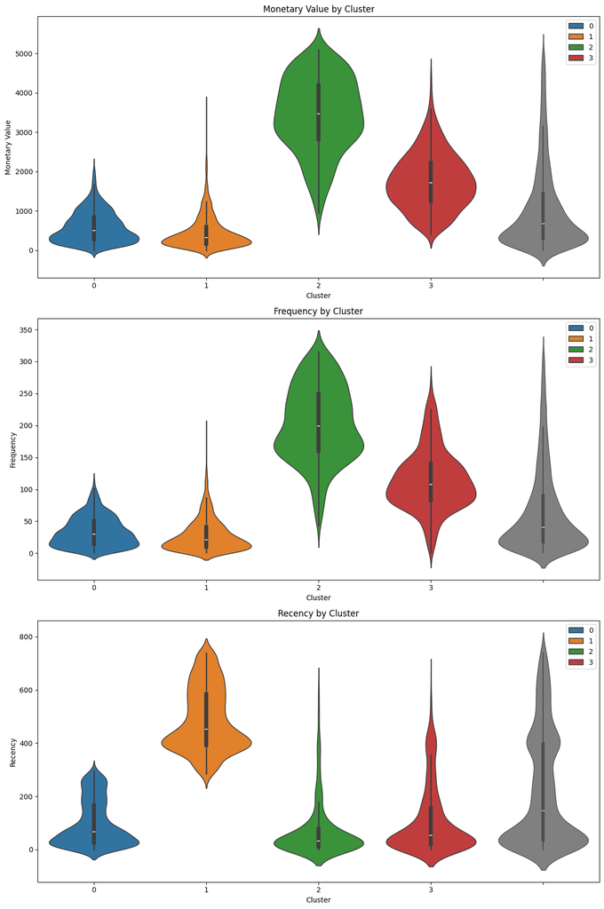

```python
plt.figure(figsize=(12, 18))

plt.subplot(3, 1, 1)
sns.violinplot(x=non_outliers_df['Cluster'], y=non_outliers_df['TotalSpending'], palette=cluster_colors, hue=non_outliers_df["Cluster"])
sns.violinplot(y=non_outliers_df['TotalSpending'], color='gray', linewidth=1.0)
plt.title('Monetary Value by Cluster')
plt.ylabel('Monetary Value')

plt.subplot(3, 1, 2)
sns.violinplot(x=non_outliers_df['Cluster'], y=non_outliers_df['Frequency'], palette=cluster_colors, hue=non_outliers_df["Cluster"])
sns.violinplot(y=non_outliers_df['Frequency'], color='gray', linewidth=1.0)
plt.title('Frequency by Cluster')
plt.ylabel('Frequency')


plt.subplot(3, 1, 3)
sns.violinplot(x=non_outliers_df['Cluster'], y=non_outliers_df['Recency'], palette=cluster_colors, hue=non_outliers_df["Cluster"])
sns.violinplot(y=non_outliers_df['Recency'], color='gray', linewidth=1.0)
plt.title('Recency by Cluster')
plt.ylabel('Recency')

plt.tight_layout()
plt.show()
```

# Non-outlier customer clusters

### Cluster 1 : Hibernating

- Violin plot analysis => their monetary and frequency are quite low compared to all data but recency is very high
- Characteristic => They have average payment and frequency but it's been a long since their last purchase
- Suggestion => They are still worth to bring them back by doing some campaigns or promotions

### Cluster 2 : Champion

- Violin plot analysis => their monetary and frequency are very high compared to which of all data and recency is also very low
- Characteristic => The most important customer which frequently buy and spent a lot of money recently.
- Suggestion => We need to keep them for the best and don't let them go no matter what

### Cluster 3 : Loyal Customers

```python
"""
Now, we will try to visualize the outlier data to see its clustering
"""

overlap_indices = monetary_outliers_df.index.intersection(frequency_outliers_df.index)

monetary_only_outliers = monetary_outliers_df.drop(overlap_indices)
frequency_only_outliers = frequency_outliers_df.drop(overlap_indices)
monetary_and_frequency_outliers = monetary_outliers_df.loc[overlap_indices]

monetary_only_outliers["Cluster"] = -1
frequency_only_outliers["Cluster"] = -2
monetary_and_frequency_outliers["Cluster"] = -3

outlier_clusters_df = pd.concat([monetary_only_outliers, frequency_only_outliers, monetary_and_frequency_outliers])

outlier_clusters_df
```

|  | Customer_ID | TotalSpending | Recency | Frequency | Cluster |
| --- | --- | --- | --- | --- | --- |
| 0 | 12346 | 77556.46 | 325 | 34 | -1 |
| 10 | 12356 | 6371.73 | 22 | 142 | -1 |
| 11 | 12357 | 18287.66 | 33 | 296 | -1 |
| 16 | 12362 | 5356.23 | 3 | 267 | -1 |
| 32 | 12378 | 5416.32 | 129 | 301 | -1 |
| ... | ... | ... | ... | ... | ... |
| 5818 | 18225 | 13014.80 | 3 | 572 | -3 |
| 5819 | 18226 | 11878.88 | 44 | 528 | -3 |
| 5824 | 18231 | 6854.17 | 192 | 383 | -3 |
| 5838 | 18245 | 6324.98 | 7 | 458 | -3 |
| 5853 | 18260 | 9947.26 | 172 | 410 | -3 |

829 rows × 5 columns

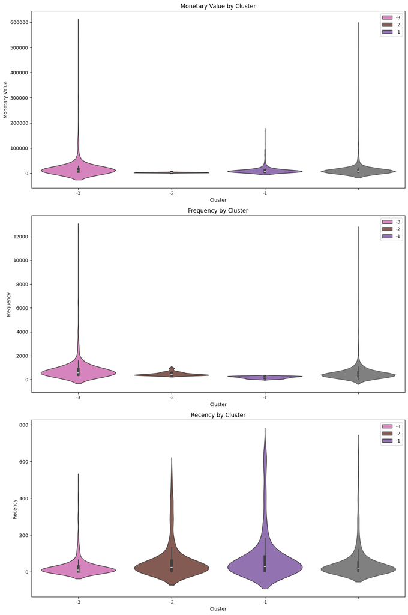

```python
cluster_colors = {-1: '#9467bd',
                  -2: '#8c564b',
                  -3: '#e377c2'}

plt.figure(figsize=(12, 18))

plt.subplot(3, 1, 1)
sns.violinplot(x=outlier_clusters_df['Cluster'], y=outlier_clusters_df['TotalSpending'], palette=cluster_colors, hue=outlier_clusters_df["Cluster"])
sns.violinplot(y=outlier_clusters_df['TotalSpending'], color='gray', linewidth=1.0)
plt.title('Monetary Value by Cluster')
plt.ylabel('Monetary Value')

plt.subplot(3, 1, 2)
sns.violinplot(x=outlier_clusters_df['Cluster'], y=outlier_clusters_df['Frequency'], palette=cluster_colors, hue=outlier_clusters_df["Cluster"])
sns.violinplot(y=outlier_clusters_df['Frequency'], color='gray', linewidth=1.0)
plt.title('Frequency by Cluster')
plt.ylabel('Frequency')

plt.subplot(3, 1, 3)
sns.violinplot(x=outlier_clusters_df['Cluster'], y=outlier_clusters_df['Recency'], palette=cluster_colors, hue=outlier_clusters_df["Cluster"])
sns.violinplot(y=outlier_clusters_df['Recency'], color='gray', linewidth=1.0)
plt.title('Recency by Cluster')
plt.ylabel('Recency')

plt.tight_layout()
plt.show()
```

# Outlier customer clusters

### Cluster -1 (Monetary Outliers)

- Characteristic => High spenders but not necessarily frequent buyers. Their purchases are large but infrequent
- Suggestion => Focus on maintaining their loyalty with personalized offers that align with their amount of spending

### Cluster -2 (Frequency Outliers):

- Characteristic => Frequent buyers who spend less per purchase. These customers are consistently engaged but might benefit from upselling opportunities
- Suggestion => Implement loyalty programs or bundle deals to encourage higher spending per visit

### Cluster -3 (Monetary & Frequency Outliers):

- Characteristic => extreme spending and frequent purchases. They are likely your top-tier customers who require special attention
- Suggestion => Develop VIP programs or exclusive offers to maintain their loyalty and encourage continued engagement

```python
cluster_labels = {
    0: "Potential Loyalist",
    1: "Hibernating",
    2: "Champion",
    3: "Loyal Customers",
    -1: "Monetary Outliers",
    -2: "Frequency Outliers",
    -3: "Monetary & Frequency Outliers"
}
```

```python
full_clustering_df = pd.concat([non_outliers_df, outlier_clusters_df])

full_clustering_df
```

|  | Customer_ID | TotalSpending | Recency | Frequency | Cluster |
| --- | --- | --- | --- | --- | --- |
| 1 | 12347 | 4921.53 | 2 | 222 | 2 |
| 2 | 12348 | 2019.40 | 75 | 51 | 3 |
| 3 | 12349 | 4428.69 | 18 | 175 | 2 |
| 4 | 12350 | 334.40 | 310 | 17 | 1 |
| 5 | 12351 | 300.93 | 375 | 21 | 1 |
| ... | ... | ... | ... | ... | ... |
| 5818 | 18225 | 13014.80 | 3 | 572 | -3 |
| 5819 | 18226 | 11878.88 | 44 | 528 | -3 |
| 5824 | 18231 | 6854.17 | 192 | 383 | -3 |
| 5838 | 18245 | 6324.98 | 7 | 458 | -3 |
| 5853 | 18260 | 9947.26 | 172 | 410 | -3 |

5881 rows × 5 columns

```python
full_clustering_df["ClusterLabel"] = full_clustering_df["Cluster"].map(cluster_labels)

full_clustering_df
```

|  | Customer_ID | TotalSpending | Recency | Frequency | Cluster | ClusterLabel |
| --- | --- | --- | --- | --- | --- | --- |
| 1 | 12347 | 4921.53 | 2 | 222 | 2 | Champion |
| 2 | 12348 | 2019.40 | 75 | 51 | 3 | Loyal Customers |
| 3 | 12349 | 4428.69 | 18 | 175 | 2 | Champion |
| 4 | 12350 | 334.40 | 310 | 17 | 1 | Hibernating |
| 5 | 12351 | 300.93 | 375 | 21 | 1 | Hibernating |
| ... | ... | ... | ... | ... | ... | ... |
| 5818 | 18225 | 13014.80 | 3 | 572 | -3 | Monetary & Frequency Outliers |
| 5819 | 18226 | 11878.88 | 44 | 528 | -3 | Monetary & Frequency Outliers |
| 5824 | 18231 | 6854.17 | 192 | 383 | -3 | Monetary & Frequency Outliers |
| 5838 | 18245 | 6324.98 | 7 | 458 | -3 | Monetary & Frequency Outliers |
| 5853 | 18260 | 9947.26 | 172 | 410 | -3 | Monetary & Frequency Outliers |

5881 rows × 6 columns

## Summary Visualization

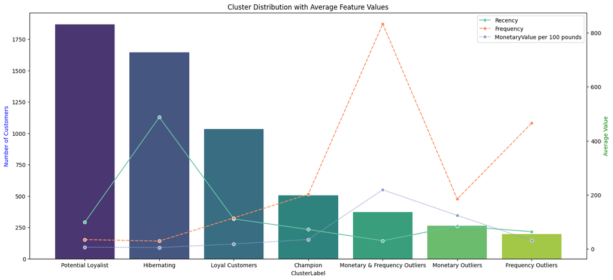

```python
cluster_counts = full_clustering_df['ClusterLabel'].value_counts()
full_clustering_df["MonetaryValue per 100 pounds"] = full_clustering_df["TotalSpending"] / 100.00
feature_means = full_clustering_df.groupby('ClusterLabel')[['Recency', 'Frequency', 'MonetaryValue per 100 pounds']].mean()

fig, ax1 = plt.subplots(figsize=(18, 8))

sns.barplot(x=cluster_counts.index, y=cluster_counts.values, ax=ax1, palette='viridis', hue=cluster_counts.index)
ax1.set_ylabel('Number of Customers', color='b')
ax1.set_title('Cluster Distribution with Average Feature Values')

ax2 = ax1.twinx()

sns.lineplot(data=feature_means, ax=ax2, palette='Set2', marker='o')
ax2.set_ylabel('Average Value', color='g')

plt.show()
```